# Clustering (STAT5003 2017)

Pengyi Yang

09 August, 2017

## Learning objective

The aim in this lecture is to understand and apply various clustering algorithms for exploratory data analysis.

## Libraries to load

```r
library(limma)
library(gplots)
library(e1071)
library(shiny)
```

## Application of clustering algorithms to Leukemia dataset

ExpressionSet containing gene expresion data from 60 bone marrow samples of patients with one of the four main types of leukemia (ALL, AML, CLL, CML) or no-leukemia controls.

Platform: Affymetrix Human Genome U133 Plus 2.0

Annotation: genemapperhgu133plus2 (CDF from GATExplorer)

Mapping: Gene Ensembl ID (20172 features)

Tissue: Bone Marrow

Cell type: Mononuclear cells isolated by Ficoll density centrifugation

Disease type:  
1. Acute Lymphoblastic Leukemia (ALL). Subtype: c-ALL / pre-B-ALL without t(9;22)  
2. Acute Myeloid Leukemia (AML). Subtype: Normal karyotype  
3. Chronic Lymphocytic Leukemia (CLL)  
4. Chronic Myeloid Leukemia (CML)  
5. Non-leukemia and healthy bone marrow (NoL)

All samples were obtained from untreated patients at the time of diagnosis. Preprocessing: The microarrays were normalized with RMA using a redefined probe mapping from Affymetrix probesets to Ensembl genes (Ensembl IDs ENSG). This alternative Chip Definition File (CDF) with complete unambiguous mapping of microarray probes to genes (GeneMapper) is available at GATExplorer (http://bioinfow.dep.usal.es/xgate/mapping/mapping.php) (Risueno et al. 2010).

```r
# load data
library(leukemiasEset)
data(leukemiasEset)
# extract expression matrix from the "ExpressionSet object"
leukemia.mat <- exprs(leukemiasEset)
# obtain and summarize phenodata
phenodata <- pData(leukemiasEset)
```

## hierarchical clustering analysis of Leukemia dataset

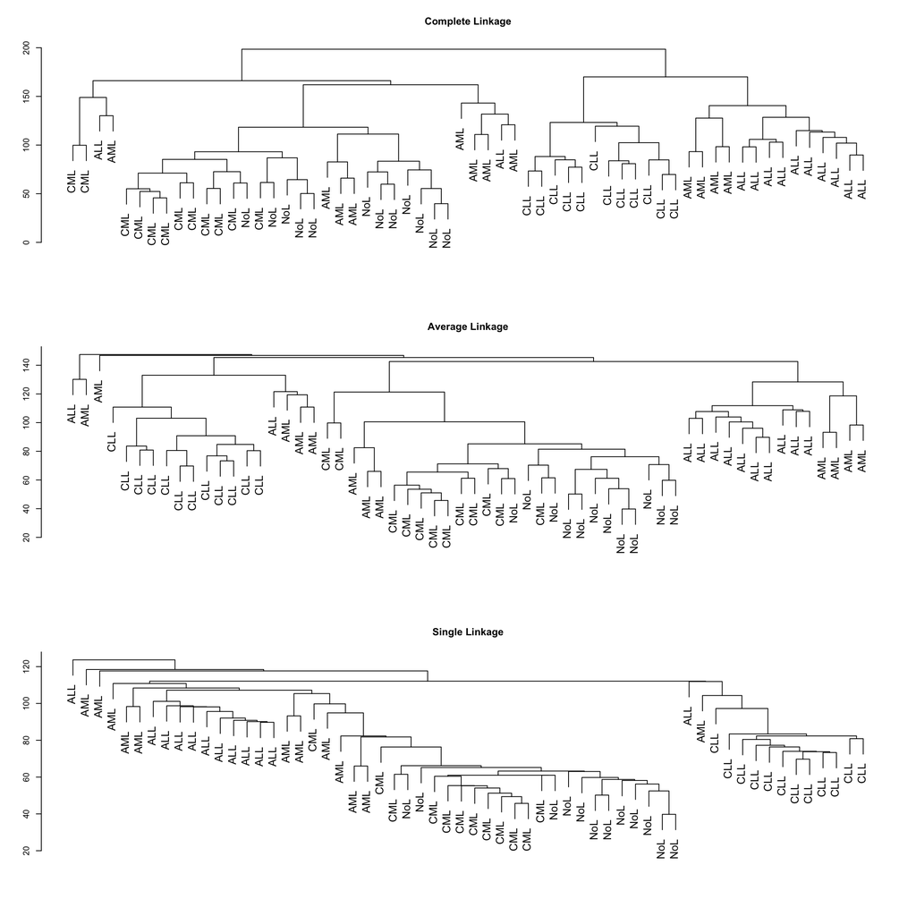

```r
labs <- phenodata[,"LeukemiaType"]
#
par(mfrow=c(3,1))
data.dist=dist(t(leukemia.mat))
plot(hclust(data.dist), labels=labs, main="Complete Linkage", xlab="", sub="",ylab="", cex=1.3)
plot(hclust(data.dist, method="average"), labels=labs, main="Average Linkage", xlab="", sub="",ylab="", cex=1.3)
plot(hclust(data.dist, method="single"), labels=labs,  main="Single Linkage", xlab="", sub="",ylab="", cex=1.3)
```

```r
hc.out=hclust(dist(t(leukemia.mat)))
hc.clusters = cutree(hc.out, 5)
table(hc.clusters, labs)
```

```
##            labs
## hc.clusters ALL AML CLL CML NoL
##           1   1   4   0   0   0
##           2   1   1   0   2   0
##           3  10   4   0   0   0
##           4   0   3   0  10  12
##           5   0   0  12   0   0
```

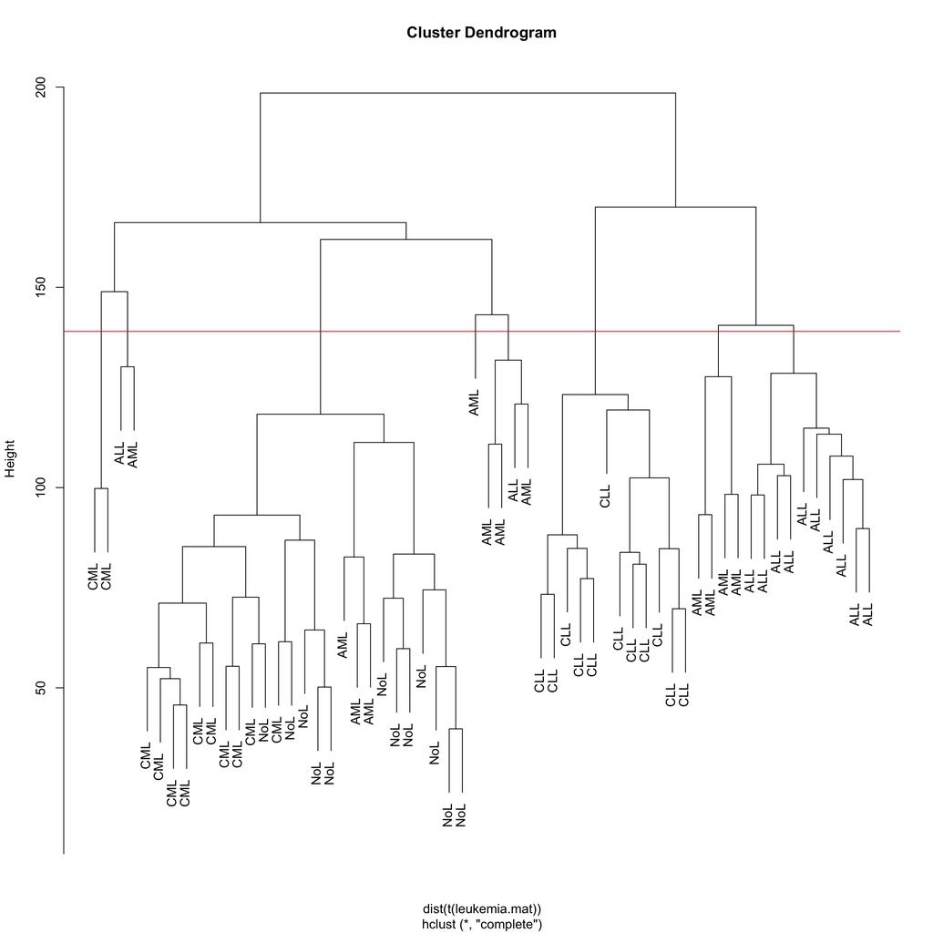

```r
par(mfrow=c(1,1))
plot(hc.out, labels = labs)
abline(h=139, col="red")
```

```r
hc.out
```

```
##
## Call:
## hclust(d = dist(t(leukemia.mat)))
##
## Cluster method   : complete
## Distance         : euclidean
## Number of objects: 60
```

### Identify and select differentially expressed genes from Leukemia dataset using LIMMA package

```r
# create the design matrix
f = phenodata[colnames(leukemia.mat), 3]
design = model.matrix(~ f - 1)
colnames(design) <- c("ALL", "AML", "CLL", "CML", "NoL")
design
```

```
##    ALL AML CLL CML NoL
## 1    1   0   0   0   0
## 2    1   0   0   0   0
## 3    1   0   0   0   0
## 4    1   0   0   0   0
## 5    1   0   0   0   0
## 6    1   0   0   0   0
## 7    1   0   0   0   0
## 8    1   0   0   0   0
## 9    1   0   0   0   0
## 10   1   0   0   0   0
## 11   1   0   0   0   0
## 12   1   0   0   0   0
## 13   0   1   0   0   0
## 14   0   1   0   0   0
```

[output cut: 51 more lines]

```r
fit <- lmFit(leukemia.mat , design) # fitting data to a linear model
contrast.matrix <- makeContrasts(ALL-NoL, AML-NoL, CLL-NoL, CML-NoL, levels=design)  # defining group comparisons
fit2 <- contrasts.fit(fit, contrast.matrix) # convert the coefficients of the design matrix into these 4 contrasts which are to be tested equal to zero
fit2 <- eBayes(fit2) # With a series of related parameter estimates & standard errors, eBayes computes moderated t-statistics of differential expression by empirical Bayes shrinkage of the standard errors towards a common value.
leukemia.topDE <-leukemia.mat[order(fit2$F.p.value), ][1:500,] # Select the top 500 most differentially expressed genes
dim(leukemia.topDE)
```

```
## [1] 500  60
```

### Use heatmap to visualize hierarchical clustering results

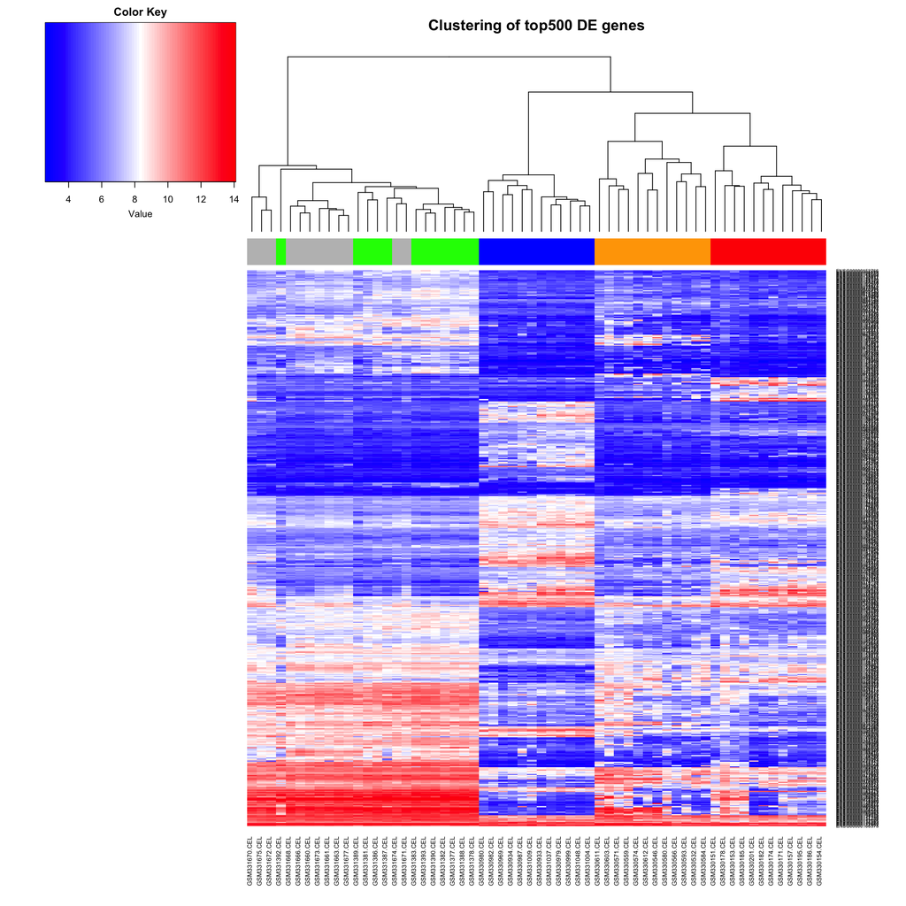

```r
patientcolors = sapply(as.character(f), switch, ALL = "red", AML =  "orange", CLL = "blue",  CML="green", NoL="gray")
heatmap.2(leukemia.topDE, col=bluered(75), ColSideColors=patientcolors, density.info="none", trace="none", na.color = "black", margins=c(8, 8), main="Clustering of top500 DE genes", dendrogram = "column")
```

## k-means based clustering algorithms

### Apply k-means clustering on iris data

```r
dim(iris)
```

```
## [1] 150   5
```

```r
head(iris)
```

```
##   Sepal.Length Sepal.Width Petal.Length Petal.Width Species
## 1          5.1         3.5          1.4         0.2  setosa
## 2          4.9         3.0          1.4         0.2  setosa
## 3          4.7         3.2          1.3         0.2  setosa
## 4          4.6         3.1          1.5         0.2  setosa
## 5          5.0         3.6          1.4         0.2  setosa
## 6          5.4         3.9          1.7         0.4  setosa
```

```r
table(iris$Species)
```

```
##
##     setosa versicolor  virginica
##         50         50         50
```

```r
class(iris)
```

```
## [1] "data.frame"
```

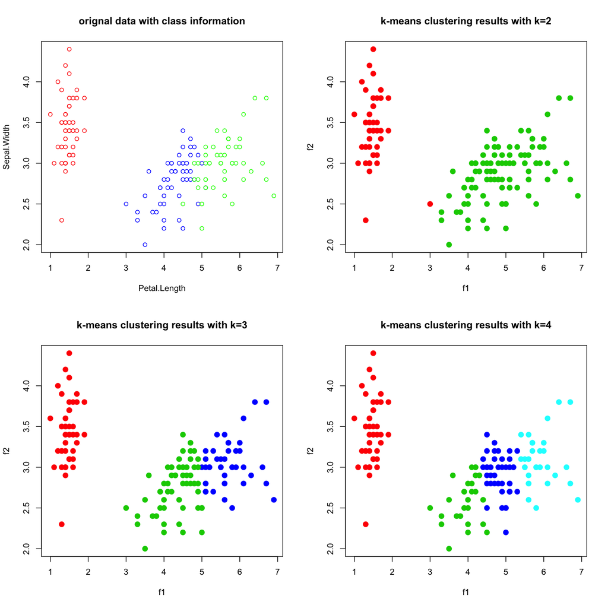

```r
# set up plots
par(mfrow=c(2,2))
# plot original data
speciesColors = sapply(as.character(iris$Species), switch, setosa = "red", versicolor = "blue",  virginica="green")
data.mat <- cbind(iris$Petal.Length, iris$Sepal.Width, iris$Species)
colnames(data.mat) <- c("Petal.Length", "Sepal.Width", "Species")
plot(data.mat[,-3], col=speciesColors, main="orignal data with class information")

# apply k-means with k=2
set.seed(1)
km.out2 <- kmeans(data.mat[,-3], centers=2)
plot(data.mat[,-3], col=(km.out2$cluster+1), main="k-means clustering results with k=2", xlab="f1", ylab="f2", pch=20, cex=2)

# apply k-means with k=3
set.seed(1)
km.out3 <- kmeans(data.mat[,-3], centers=3)
plot(data.mat[,-3], col=(km.out3$cluster+1), main="k-means clustering results with k=3", xlab="f1", ylab="f2", pch=20, cex=2)

# apply k-means with k=4
set.seed(1)
km.out4 <- kmeans(data.mat[,-3], centers=4)
plot(data.mat[,-3], col=(km.out4$cluster+1), main="k-means clustering results with k=4", xlab="f1", ylab="f2", pch=20, cex=2)
```

### Cluster statitics

```r
# what is the output from k-means clustering?
km.out2
```

```
## K-means clustering with 2 clusters of sizes 51, 99
##
## Cluster means:
##   Petal.Length Sepal.Width
## 1     1.492157    3.409804
## 2     4.925253    2.875758
##
## Clustering vector:
##   [1] 1 1 1 1 1 1 1 1 1 1 1 1 1 1 1 1 1 1 1 1 1 1 1 1 1 1 1 1 1 1 1 1 1 1 1
##  [36] 1 1 1 1 1 1 1 1 1 1 1 1 1 1 1 2 2 2 2 2 2 2 2 2 2 2 2 2 2 2 2 2 2 2 2
##  [71] 2 2 2 2 2 2 2 2 2 2 2 2 2 2 2 2 2 2 2 2 2 2 2 2 2 2 2 2 1 2 2 2 2 2 2
## [106] 2 2 2 2 2 2 2 2 2 2 2 2 2 2 2 2 2 2 2 2 2 2 2 2 2 2 2 2 2 2 2 2 2 2 2
## [141] 2 2 2 2 2 2 2 2 2 2
##
## Within cluster sum of squares by cluster:
## [1] 11.68196 74.62869
##  (between_SS / total_SS =  82.5 %)
##
## Available components:
##
## [1] "cluster"      "centers"      "totss"        "withinss"
## [5] "tot.withinss" "betweenss"    "size"         "iter"
## [9] "ifault"
```

```r
# check between and within cluster sum of squares.
km.out2$betweenss
```

```
## [1] 406.3217
```

```r
km.out2$tot.withinss
```

```
## [1] 86.31065
```

```r
km.out3$betweenss
```

```
## [1] 451.8953
```

```r
km.out3$tot.withinss
```

```
## [1] 40.73707
```

```r
km.out4$betweenss
```

```
## [1] 465.1476
```

```r
km.out4$tot.withinss
```

```
## [1] 27.4847
```

### Application of c-means clustering

notice that we use the **membership** score to control the size of the point to plot. k-means clustering algorithm will not create membership score and will create a hard clustering whereas c-means gives membership score which can be used as a confidence meansure of clustering for each sample.

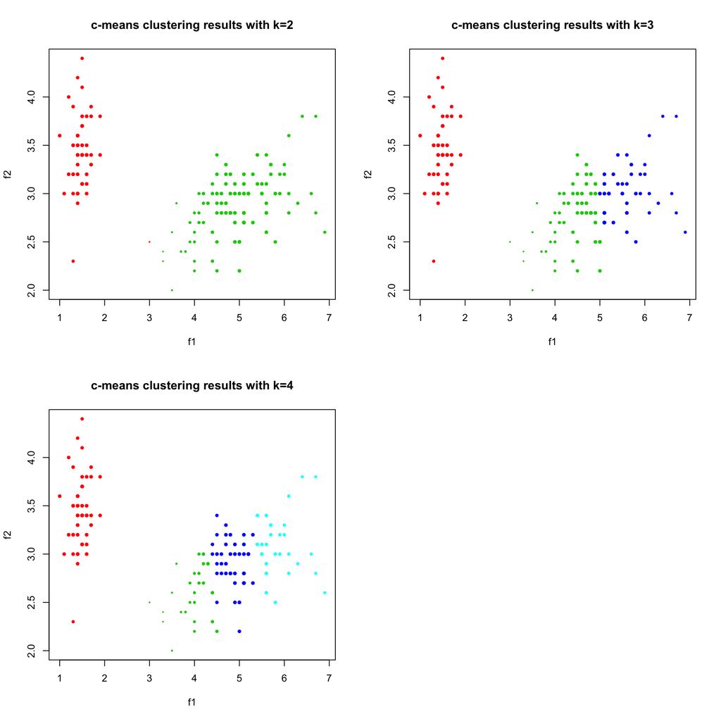

```r
# set up plots
par(mfrow=c(2,2))
# apply c-means with k=1
set.seed(1)
cm.out2 <- cmeans(data.mat[,-3], centers=2, m = 2)
plot(data.mat[,-3], col=(cm.out2$cluster+1), main="c-means clustering results with k=2", xlab="f1", ylab="f2", pch=20, cex=apply(cm.out2$membership, 1, max)^2)

# apply c-means with k=3
set.seed(1)
cm.out3 <- cmeans(data.mat[,-3], centers=3)
plot(data.mat[,-3], col=(cm.out3$cluster+1), main="c-means clustering results with k=3", xlab="f1", ylab="f2", pch=20, cex=apply(cm.out2$membership, 1, max)^2)

# apply c-means with k=4
set.seed(1)
cm.out4 <- cmeans(data.mat[,-3], centers=4)
plot(data.mat[,-3], col=(cm.out4$cluster+1), main="c-means clustering results with k=4", xlab="f1", ylab="f2", pch=20, cex=apply(cm.out2$membership, 1, max)^2)
```

## Clustering results validation

### data structure based metrics

The internal measures include the connectivity, and Silhouette Width, and Dunn Index. The connectivity indicates the degree of connectedness of the clusters, as determined by the k-nearest neighbors. The neighbSize argument specifies the number of neighbors to use. The connectivity has a value between 0 and infinity and should be minimized. Both the Silhouette Width and the Dunn Index combine measures of compactness and separation of the clusters. The Silhouette Width is the average of each observation’s Silhouette value. The Silhouette value measures the degree of confidence in a particular clustering assignment and lies in the interval [-1,1], with well-clustered observations having values near 1 and poorly clustered observations having values near -1.

```r
library(clValid) # clValid is a package that containing various cluster validation methods
intern <- clValid(data.mat[,-3], nClust=2:10, validation="internal", clMethods=c("hierarchical","kmeans", "pam"))
summary(intern)
```

```
##
## Clustering Methods:
##  hierarchical kmeans pam
##
## Cluster sizes:
##  2 3 4 5 6 7 8 9 10
##
## Validation Measures:
##                                  2       3       4       5       6       7       8       9      10
##
## hierarchical Connectivity   0.0000  4.4480  7.3770 14.5361 20.2313 25.1183 31.5460 37.8452 43.6540
##              Dunn           0.3624  0.0866  0.0866  0.0828  0.0869  0.0941  0.1088  0.1088  0.1143
##              Silhouette     0.7410  0.6057  0.5098  0.4823  0.4621  0.4650  0.4133  0.3864  0.3714
## kmeans       Connectivity   3.6956  9.9992 17.3873 21.9770 36.9917 43.8742 49.0389 56.9567 62.6937
##              Dunn           0.0851  0.0471  0.0471  0.0588  0.0654  0.0707  0.0707  0.0769  0.1015
##              Silhouette     0.7393  0.5990  0.4562  0.4271  0.4093  0.4052  0.3987  0.3818  0.3767
## pam          Connectivity   3.6956 14.2563 13.6988 23.9639 36.3048 44.0825 53.0603 63.1389 63.4611
##              Dunn           0.0851  0.0428  0.0670  0.0474  0.0474  0.0632  0.0632  0.0632  0.0877
##              Silhouette     0.7393  0.5847  0.5554  0.5079  0.4984  0.3740  0.3481  0.3330  0.3573
##
## Optimal Scores:
##
##              Score  Method       Clusters
## Connectivity 0.0000 hierarchical 2
## Dunn         0.3624 hierarchical 2
## Silhouette   0.7410 hierarchical 2
```

```r
optimalScores(intern)
```

```
##                  Score       Method Clusters
## Connectivity 0.0000000 hierarchical        2
## Dunn         0.3624078 hierarchical        2
## Silhouette   0.7410049 hierarchical        2
```

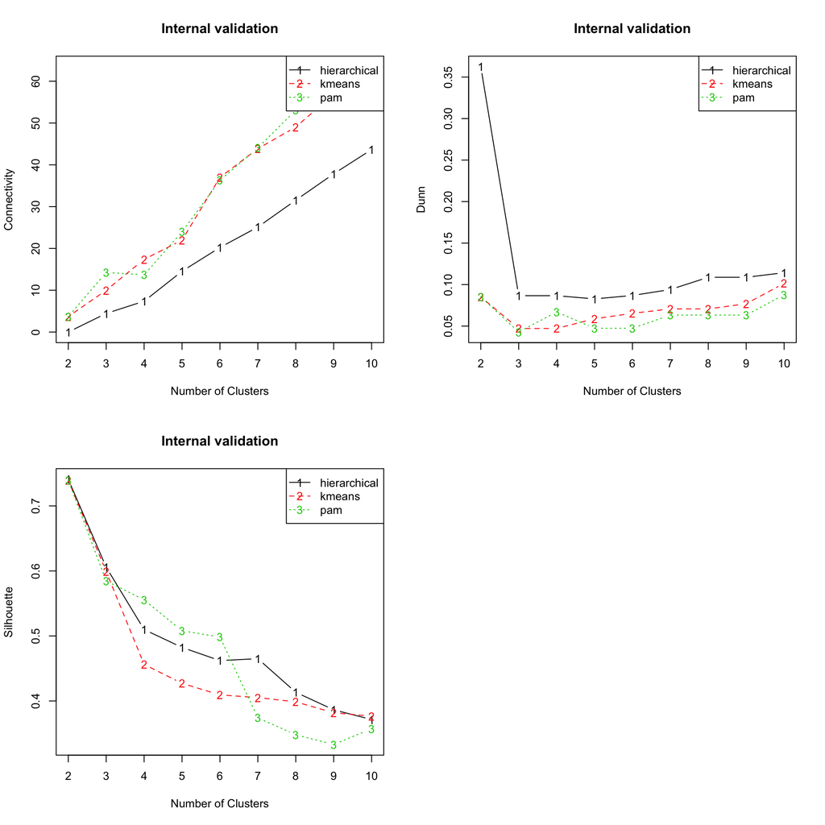

```r
# set up plots
par(mfrow=c(2,2))
plot(intern)
```

### stability based metrics

The stability measures evaluate the stability of a clustering result by comparing it with the clusters obtained by removing one column at a time. These measures include the average proportion of non-overlap (APN), the average distance (AD), the average distance between means (ADM), and the figure of merit (FOM). The APN, AD, and ADM are all based on the cross-classification table of the original clustering with the clustering based on the removal of one column. The APN measures the average proportion of observations not placed in the same cluster under both cases, while the AD measures the average distance between observations placed in the same cluster under both cases and the ADM measures the average distance between cluster centers for observations placed in the same cluster under both cases. The FOM measures the average intra-cluster variance of the deleted column, where the clustering is based on the remaining (undeleted) columns. In all cases the average is taken over all the deleted columns, and all measures should be minimized.

```r
par(mfrow=c(2,2))
stab <- clValid(iris[,-5], nClust=2:10, validation="stability", clMethods=c("hierarchical", "kmeans", "pam"))
optimalScores(stab)
```

```
##         Score       Method Clusters
## APN 0.0000000 hierarchical        2
## AD  0.6252553          pam       10
## ADM 0.0000000 hierarchical        2
## FOM 0.2841429          pam        9
```

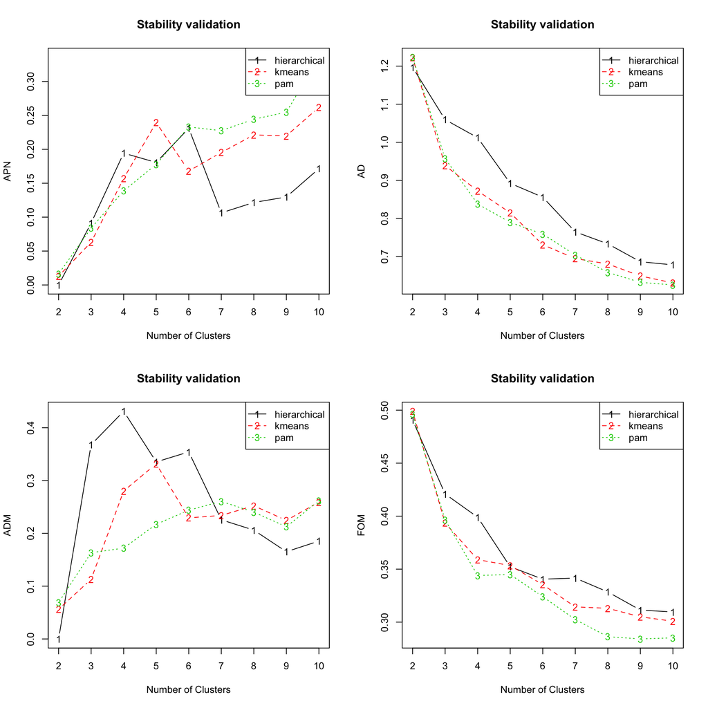

```r
plot(stab)
```